# Assignment: Advanced Regression

## Data Understanding and Exploration

##### Let's first have a look at the dataset and understand the size, attribute names etc.

Import necessary liabraries

Performing baisc checks in the dataset

```python
import numpy as np
import pandas as pd
import matplotlib.pyplot as plt
import seaborn as sns
from sklearn import linear_model
from sklearn.linear_model import LinearRegression
from sklearn.linear_model import Ridge
from sklearn.linear_model import Lasso
from sklearn.model_selection import GridSearchCV
from sklearn.model_selection import cross_val_score

# To Scale our data
from sklearn.preprocessing import scale
from sklearn.preprocessing import StandardScaler
from sklearn.model_selection import train_test_split
import os
from sklearn.metrics import r2_score


# hide warnings
import warnings
warnings.filterwarnings('ignore')

pd.set_option('display.max_rows', 100)
pd.set_option('display.max_columns', 100)


%matplotlib inline
```

```python
# Reading the dataset
house = pd.read_csv('C:\\Users\\MANLAP02\\Downloads\\train.csv')
```

```python
house.head()
```

|  | Id | MSSubClass | MSZoning | LotFrontage | LotArea | Street | Alley | LotShape | LandContour | Utilities | LotConfig | LandSlope | Neighborhood | Condition1 | Condition2 | BldgType | HouseStyle | OverallQual | OverallCond | YearBuilt | YearRemodAdd | RoofStyle | RoofMatl | Exterior1st | Exterior2nd | MasVnrType | MasVnrArea | ExterQual | ExterCond | … |
| --- | --- | --- | --- | --- | --- | --- | --- | --- | --- | --- | --- | --- | --- | --- | --- | --- | --- | --- | --- | --- | --- | --- | --- | --- | --- | --- | --- | --- | --- | --- |
| 0 | 1 | 60 | RL | 65.0 | 8450 | Pave | NaN | Reg | Lvl | AllPub | Inside | Gtl | CollgCr | Norm | Norm | 1Fam | 2Story | 7 | 5 | 2003 | 2003 | Gable | CompShg | VinylSd | VinylSd | BrkFace | 196.0 | Gd | TA | … |
| 1 | 2 | 20 | RL | 80.0 | 9600 | Pave | NaN | Reg | Lvl | AllPub | FR2 | Gtl | Veenker | Feedr | Norm | 1Fam | 1Story | 6 | 8 | 1976 | 1976 | Gable | CompShg | MetalSd | MetalSd | None | 0.0 | TA | TA | … |
| 2 | 3 | 60 | RL | 68.0 | 11250 | Pave | NaN | IR1 | Lvl | AllPub | Inside | Gtl | CollgCr | Norm | Norm | 1Fam | 2Story | 7 | 5 | 2001 | 2002 | Gable | CompShg | VinylSd | VinylSd | BrkFace | 162.0 | Gd | TA | … |
| 3 | 4 | 70 | RL | 60.0 | 9550 | Pave | NaN | IR1 | Lvl | AllPub | Corner | Gtl | Crawfor | Norm | Norm | 1Fam | 2Story | 7 | 5 | 1915 | 1970 | Gable | CompShg | Wd Sdng | Wd Shng | None | 0.0 | TA | TA | … |
| 4 | 5 | 60 | RL | 84.0 | 14260 | Pave | NaN | IR1 | Lvl | AllPub | FR2 | Gtl | NoRidge | Norm | Norm | 1Fam | 2Story | 8 | 5 | 2000 | 2000 | Gable | CompShg | VinylSd | VinylSd | BrkFace | 350.0 | Gd | TA | … |

```python
house.shape
```

```
(1460, 81)
```

```python
house.info()
```

```
<class 'pandas.core.frame.DataFrame'>
RangeIndex: 1460 entries, 0 to 1459
Data columns (total 81 columns):
 #   Column         Non-Null Count  Dtype
---  ------         --------------  -----
 0   Id             1460 non-null   int64
 1   MSSubClass     1460 non-null   int64
 2   MSZoning       1460 non-null   object
 3   LotFrontage    1201 non-null   float64
 4   LotArea        1460 non-null   int64
 5   Street         1460 non-null   object
 6   Alley          91 non-null     object
 7   LotShape       1460 non-null   object
 8   LandContour    1460 non-null   object
 9   Utilities      1460 non-null   object
```

[output cut: 73 more lines]

```python
house.describe([0.25,0.50,0.75,0.99])
```

|  | Id | MSSubClass | LotFrontage | LotArea | OverallQual | OverallCond | YearBuilt | YearRemodAdd | MasVnrArea | BsmtFinSF1 | BsmtFinSF2 | BsmtUnfSF | TotalBsmtSF | 1stFlrSF | 2ndFlrSF | LowQualFinSF | GrLivArea | BsmtFullBath | BsmtHalfBath | FullBath | HalfBath | BedroomAbvGr | KitchenAbvGr | TotRmsAbvGrd | Fireplaces | GarageYrBlt | GarageCars | GarageArea | WoodDeckSF | … |
| --- | --- | --- | --- | --- | --- | --- | --- | --- | --- | --- | --- | --- | --- | --- | --- | --- | --- | --- | --- | --- | --- | --- | --- | --- | --- | --- | --- | --- | --- | --- |
| count | 1460.000000 | 1460.000000 | 1201.000000 | 1460.000000 | 1460.000000 | 1460.000000 | 1460.000000 | 1460.000000 | 1452.000000 | 1460.000000 | 1460.000000 | 1460.000000 | 1460.000000 | 1460.000000 | 1460.000000 | 1460.000000 | 1460.000000 | 1460.000000 | 1460.000000 | 1460.000000 | 1460.000000 | 1460.000000 | 1460.000000 | 1460.000000 | 1460.000000 | 1379.000000 | 1460.000000 | 1460.000000 | 1460.000000 | … |
| mean | 730.500000 | 56.897260 | 70.049958 | 10516.828082 | 6.099315 | 5.575342 | 1971.267808 | 1984.865753 | 103.685262 | 443.639726 | 46.549315 | 567.240411 | 1057.429452 | 1162.626712 | 346.992466 | 5.844521 | 1515.463699 | 0.425342 | 0.057534 | 1.565068 | 0.382877 | 2.866438 | 1.046575 | 6.517808 | 0.613014 | 1978.506164 | 1.767123 | 472.980137 | 94.244521 | … |
| std | 421.610009 | 42.300571 | 24.284752 | 9981.264932 | 1.382997 | 1.112799 | 30.202904 | 20.645407 | 181.066207 | 456.098091 | 161.319273 | 441.866955 | 438.705324 | 386.587738 | 436.528436 | 48.623081 | 525.480383 | 0.518911 | 0.238753 | 0.550916 | 0.502885 | 0.815778 | 0.220338 | 1.625393 | 0.644666 | 24.689725 | 0.747315 | 213.804841 | 125.338794 | … |
| min | 1.000000 | 20.000000 | 21.000000 | 1300.000000 | 1.000000 | 1.000000 | 1872.000000 | 1950.000000 | 0.000000 | 0.000000 | 0.000000 | 0.000000 | 0.000000 | 334.000000 | 0.000000 | 0.000000 | 334.000000 | 0.000000 | 0.000000 | 0.000000 | 0.000000 | 0.000000 | 0.000000 | 2.000000 | 0.000000 | 1900.000000 | 0.000000 | 0.000000 | 0.000000 | … |
| 25% | 365.750000 | 20.000000 | 59.000000 | 7553.500000 | 5.000000 | 5.000000 | 1954.000000 | 1967.000000 | 0.000000 | 0.000000 | 0.000000 | 223.000000 | 795.750000 | 882.000000 | 0.000000 | 0.000000 | 1129.500000 | 0.000000 | 0.000000 | 1.000000 | 0.000000 | 2.000000 | 1.000000 | 5.000000 | 0.000000 | 1961.000000 | 1.000000 | 334.500000 | 0.000000 | … |
| 50% | 730.500000 | 50.000000 | 69.000000 | 9478.500000 | 6.000000 | 5.000000 | 1973.000000 | 1994.000000 | 0.000000 | 383.500000 | 0.000000 | 477.500000 | 991.500000 | 1087.000000 | 0.000000 | 0.000000 | 1464.000000 | 0.000000 | 0.000000 | 2.000000 | 0.000000 | 3.000000 | 1.000000 | 6.000000 | 1.000000 | 1980.000000 | 2.000000 | 480.000000 | 0.000000 | … |
| 75% | 1095.250000 | 70.000000 | 80.000000 | 11601.500000 | 7.000000 | 6.000000 | 2000.000000 | 2004.000000 | 166.000000 | 712.250000 | 0.000000 | 808.000000 | 1298.250000 | 1391.250000 | 728.000000 | 0.000000 | 1776.750000 | 1.000000 | 0.000000 | 2.000000 | 1.000000 | 3.000000 | 1.000000 | 7.000000 | 1.000000 | 2002.000000 | 2.000000 | 576.000000 | 168.000000 | … |
| 99% | 1445.410000 | 190.000000 | 141.000000 | 37567.640000 | 10.000000 | 9.000000 | 2009.000000 | 2009.000000 | 791.920000 | 1572.410000 | 830.380000 | 1797.050000 | 2155.050000 | 2219.460000 | 1418.920000 | 360.000000 | 3123.480000 | 2.000000 | 1.000000 | 3.000000 | 1.000000 | 5.000000 | 2.000000 | 11.000000 | 2.000000 | 2009.000000 | 3.000000 | 1002.790000 | 505.460000 | … |
| max | 1460.000000 | 190.000000 | 313.000000 | 215245.000000 | 10.000000 | 9.000000 | 2010.000000 | 2010.000000 | 1600.000000 | 5644.000000 | 1474.000000 | 2336.000000 | 6110.000000 | 4692.000000 | 2065.000000 | 572.000000 | 5642.000000 | 3.000000 | 2.000000 | 3.000000 | 2.000000 | 8.000000 | 3.000000 | 14.000000 | 3.000000 | 2010.000000 | 4.000000 | 1418.000000 | 857.000000 | … |

```python
#Check missing percentage
percent_missing = (house.isnull().sum() / house.isnull().count()*100).sort_values(ascending = False)
percent_missing.head(15)
```

```
PoolQC          99.520548
MiscFeature     96.301370
Alley           93.767123
Fence           80.753425
FireplaceQu     47.260274
LotFrontage     17.739726
GarageCond       5.547945
GarageType       5.547945
GarageYrBlt      5.547945
GarageFinish     5.547945
GarageQual       5.547945
BsmtExposure     2.602740
BsmtFinType2     2.602740
BsmtFinType1     2.534247
BsmtCond         2.534247
dtype: float64
```

```python
# Dropping Columns with high missing values ,above 40%

house.drop(['PoolQC','MiscFeature','Alley','Fence','FireplaceQu'],axis=1,inplace=True)
```

```python
house[['LotFrontage','MasVnrArea','GarageYrBlt']].describe()
```

|  | LotFrontage | MasVnrArea | GarageYrBlt |
| --- | --- | --- | --- |
| count | 1201.000000 | 1452.000000 | 1379.000000 |
| mean | 70.049958 | 103.685262 | 1978.506164 |
| std | 24.284752 | 181.066207 | 24.689725 |
| min | 21.000000 | 0.000000 | 1900.000000 |
| 25% | 59.000000 | 0.000000 | 1961.000000 |
| 50% | 69.000000 | 0.000000 | 1980.000000 |
| 75% | 80.000000 | 166.000000 | 2002.000000 |
| max | 313.000000 | 1600.000000 | 2010.000000 |

```python
#Treaing missing values by imputing for columns with missing values less than or equal to 40%

house['LotFrontage']= house.LotFrontage.fillna(house.LotFrontage.median()) #Can see a presence of outlier so imputing the missing values through median
house['MasVnrArea']= house.MasVnrArea.fillna(house.MasVnrArea.median())    # Can see presence of outlier
house['GarageYrBlt']= house.GarageYrBlt.fillna(house.GarageYrBlt.mean())  # it looks stable with no outlier presence so we can use mean for imputation
```

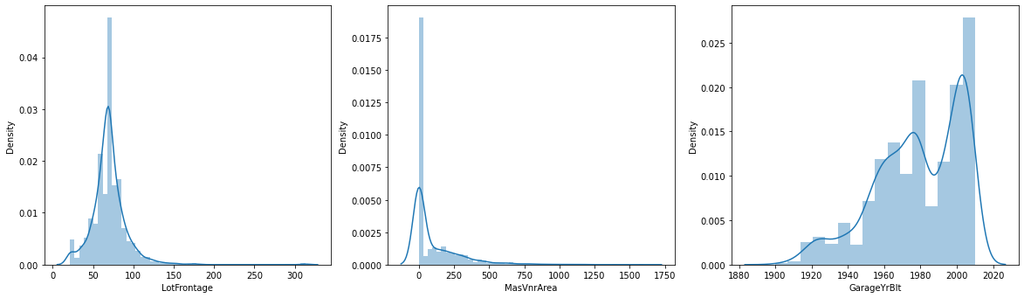

```python
plt.figure(figsize=(20, 12))
plt.subplot(2,3,1)
sns.distplot(house['LotFrontage'])
plt.subplot(2,3,2)
sns.distplot(house['MasVnrArea'])
plt.subplot(2,3,3)
sns.distplot(house['GarageYrBlt'])
```

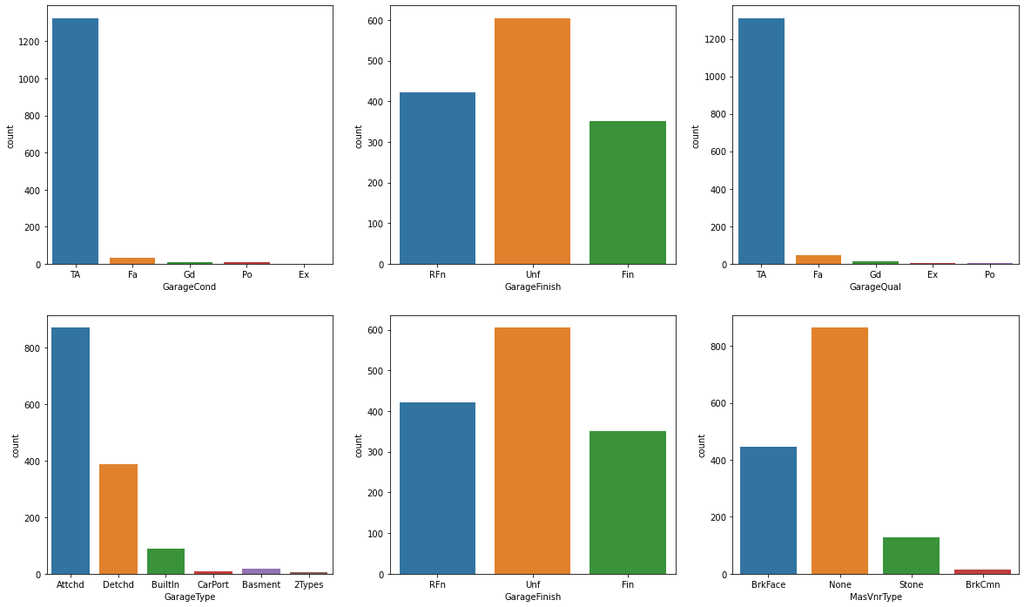

```python
#Visualising the variables wih missing values

plt.figure(figsize=(20, 12))
plt.subplot(2,3,1)
sns.countplot(x = 'GarageCond', data = house)

plt.subplot(2,3,2)
sns.countplot(x = 'GarageFinish',  data = house)

plt.subplot(2,3,3)
sns.countplot(x = 'GarageQual', data = house)
plt.subplot(2,3,4)
sns.countplot(x = 'GarageType', data = house)
plt.subplot(2,3,5)
sns.countplot(x = 'GarageFinish',  data = house)
plt.subplot(2,3,6)
sns.countplot(x = 'MasVnrType', data = house)
plt.show()
```

```python
# Cases when the house doesn't have the garrage so replacing null with No Garrage

house['GarageType'] = house['GarageType'].replace(np.nan, 'No Garage')
house['GarageFinish'] = house['GarageFinish'].replace(np.nan, 'No Garage')
house['GarageCond'] = house['GarageCond'].replace(np.nan, 'No Garage')
house['GarageQual'] = house['GarageQual'].replace(np.nan, 'No Garage')
house['MasVnrType'] = house['MasVnrType'].replace(np.nan, 'None') # replacing nan with the top option of this field
house['Electrical'] = house['Electrical'].replace(np.nan, 'SBrkr') # replacing nan with the top option of this field
```

```python
#changing num to categorical so as to form these as dummy variables
house['MSSubClass']=house['MSSubClass'].replace({20:'1-STORY 1946 & NEWER ALL STYLES',30:'1-STORY 1945 & OLDER',40:'1-STORY W/FINISHED ATTIC ALL AGES',
        45:'1-1/2 STORY - UNFINISHED ALL AGES',
        50:'1-1/2 STORY FINISHED ALL AGES',
        60:'2-STORY 1946 & NEWER',
        70:'2-STORY 1945 & OLDER',
        75:'2-1/2 STORY ALL AGES',
        80:'SPLIT OR MULTI-LEVEL',
        85:'SPLIT FOYER',
        90:'DUPLEX - ALL STYLES AND AGES',
       120:'1-STORY PUD (Planned Unit Development) - 1946 & NEWER',
       150:'1-1/2 STORY PUD - ALL AGES',
       160:'2-STORY PUD - 1946 & NEWER',
       180:'PUD - MULTILEVEL - INCL SPLIT LEV/FOYER',
       190:'2 FAMILY CONVERSION - ALL STYLES AND AGES'})

house['OverallQual']=house['OverallQual'].replace({ 10:'Very Excellent',
       9:'Excellent',
       8:'Very Good',
       7:'Good',
       6:'Above Average',
       5:'Average',
       4:'Below Average',
       3:'Fair',
       2:'Poor',
       1:'Very Poor'})
house['OverallCond']=house['OverallCond'].replace({ 10:'Very Excellent',
       9:'Excellent',
       8:'Very Good',
       7:'Good',
       6:'Above Average',
       5:'Average',
       4:'Below Average',
       3:'Fair',
       2:'Poor',
       1:'Very Poor'})
```

```python
house.head()
```

|  | Id | MSSubClass | MSZoning | LotFrontage | LotArea | Street | LotShape | LandContour | Utilities | LotConfig | LandSlope | Neighborhood | Condition1 | Condition2 | BldgType | HouseStyle | OverallQual | OverallCond | YearBuilt | YearRemodAdd | RoofStyle | RoofMatl | Exterior1st | Exterior2nd | MasVnrType | MasVnrArea | ExterQual | ExterCond | Foundation | … |
| --- | --- | --- | --- | --- | --- | --- | --- | --- | --- | --- | --- | --- | --- | --- | --- | --- | --- | --- | --- | --- | --- | --- | --- | --- | --- | --- | --- | --- | --- | --- |
| 0 | 1 | 2-STORY 1946 & NEWER | RL | 65.0 | 8450 | Pave | Reg | Lvl | AllPub | Inside | Gtl | CollgCr | Norm | Norm | 1Fam | 2Story | Good | Average | 2003 | 2003 | Gable | CompShg | VinylSd | VinylSd | BrkFace | 196.0 | Gd | TA | PConc | … |
| 1 | 2 | 1-STORY 1946 & NEWER ALL STYLES | RL | 80.0 | 9600 | Pave | Reg | Lvl | AllPub | FR2 | Gtl | Veenker | Feedr | Norm | 1Fam | 1Story | Above Average | Very Good | 1976 | 1976 | Gable | CompShg | MetalSd | MetalSd | None | 0.0 | TA | TA | CBlock | … |
| 2 | 3 | 2-STORY 1946 & NEWER | RL | 68.0 | 11250 | Pave | IR1 | Lvl | AllPub | Inside | Gtl | CollgCr | Norm | Norm | 1Fam | 2Story | Good | Average | 2001 | 2002 | Gable | CompShg | VinylSd | VinylSd | BrkFace | 162.0 | Gd | TA | PConc | … |
| 3 | 4 | 2-STORY 1945 & OLDER | RL | 60.0 | 9550 | Pave | IR1 | Lvl | AllPub | Corner | Gtl | Crawfor | Norm | Norm | 1Fam | 2Story | Good | Average | 1915 | 1970 | Gable | CompShg | Wd Sdng | Wd Shng | None | 0.0 | TA | TA | BrkTil | … |
| 4 | 5 | 2-STORY 1946 & NEWER | RL | 84.0 | 14260 | Pave | IR1 | Lvl | AllPub | FR2 | Gtl | NoRidge | Norm | Norm | 1Fam | 2Story | Very Good | Average | 2000 | 2000 | Gable | CompShg | VinylSd | VinylSd | BrkFace | 350.0 | Gd | TA | PConc | … |

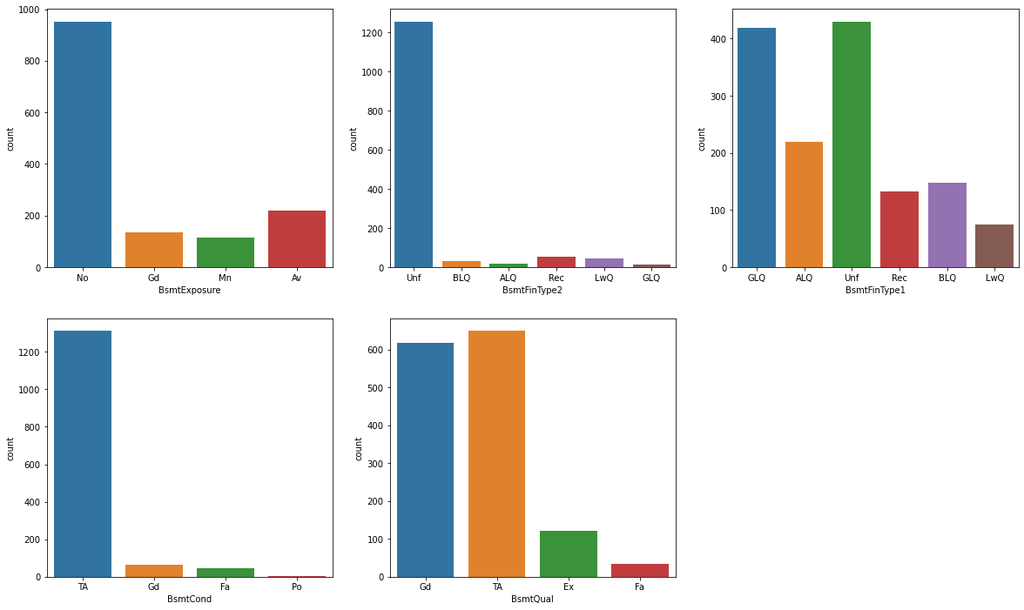

```python
plt.figure(figsize=(20, 12))
plt.subplot(2,3,1)
sns.countplot(x = 'BsmtExposure', data = house)

plt.subplot(2,3,2)
sns.countplot(x = 'BsmtFinType2',  data = house)

plt.subplot(2,3,3)
sns.countplot(x = 'BsmtFinType1', data = house)
plt.subplot(2,3,4)
sns.countplot(x = 'BsmtCond', data = house)
plt.subplot(2,3,5)
sns.countplot(x = 'BsmtQual',  data = house)

plt.show()
```

```python
# Cases when the house doesn't have the basement so replacing null with No Basement

house['BsmtExposure'] = house['BsmtExposure'].replace(np.nan, 'No Basement')
house['BsmtFinType2'] = house['BsmtFinType2'].replace(np.nan, 'No Basement')
house['BsmtFinType1'] = house['BsmtFinType1'].replace(np.nan, 'No Basement')
house['BsmtCond'] = house['BsmtCond'].replace(np.nan, 'No Basement')
house['BsmtQual'] = house['BsmtQual'].replace(np.nan, 'No Basement')
```

```python
#check missing percentage
percent_missing = (house.isnull().sum() / house.isnull().count()*100).sort_values(ascending = False)
percent_missing.head(10)
```

```
SalePrice      0.0
ExterCond      0.0
RoofStyle      0.0
RoofMatl       0.0
Exterior1st    0.0
Exterior2nd    0.0
MasVnrType     0.0
MasVnrArea     0.0
ExterQual      0.0
Foundation     0.0
dtype: float64
```

### All the missing values has been treated

```python
#Let's check the dependent variable i.e SalePrice

#descriptive statistics summary
house['SalePrice'].describe()
```

```
count      1460.000000
mean     180921.195890
std       79442.502883
min       34900.000000
25%      129975.000000
50%      163000.000000
75%      214000.000000
max      755000.000000
Name: SalePrice, dtype: float64
```

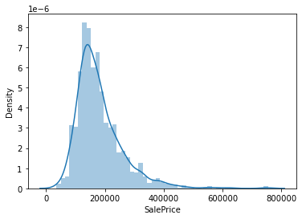

```python
sns.distplot(house['SalePrice']) #it's skewed
```

```python
#skewness and kurtosis
print("Skewness: %f" % house['SalePrice'].skew())
```

```
Skewness: 1.882876
```

```python
house['SalePrice']=np.log(house.SalePrice) #tranforming to form normal disribution
```

```python
house['SalePrice'].describe()
```

```
count    1460.000000
mean       12.024051
std         0.399452
min        10.460242
25%        11.775097
50%        12.001505
75%        12.273731
max        13.534473
Name: SalePrice, dtype: float64
```

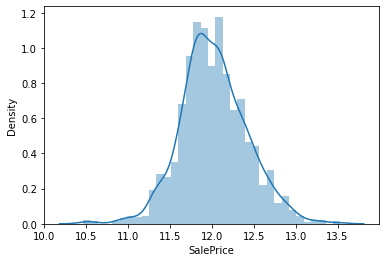

```python
sns.distplot(house['SalePrice']) # Normally distributed now
```

```python
#skewness
print("Skewness: %f" % house['SalePrice'].skew())
```

```
Skewness: 0.121335
```

#### We can say that now Dependent variable SalePrice is normally distributed.

## EDA

#### Let's check all the Categorical columns and their effect on price

```python
Cat = house.select_dtypes(include=['object'])
Cat.columns
```

```
Index(['MSSubClass', 'MSZoning', 'Street', 'LotShape', 'LandContour',
       'Utilities', 'LotConfig', 'LandSlope', 'Neighborhood', 'Condition1',
       'Condition2', 'BldgType', 'HouseStyle', 'OverallQual', 'OverallCond',
       'RoofStyle', 'RoofMatl', 'Exterior1st', 'Exterior2nd', 'MasVnrType',
       'ExterQual', 'ExterCond', 'Foundation', 'BsmtQual', 'BsmtCond',
       'BsmtExposure', 'BsmtFinType1', 'BsmtFinType2', 'Heating', 'HeatingQC',
       'CentralAir', 'Electrical', 'KitchenQual', 'Functional', 'GarageType',
       'GarageFinish', 'GarageQual', 'GarageCond', 'PavedDrive', 'SaleType',
       'SaleCondition'],
      dtype='object')
```

```python
# As we have many columns so let's make groups randomly and visualize them
# We would be making two graphs to understand firstly the countplot and secondaly effect of that variable on dependent variable i.e. SalePrice
```

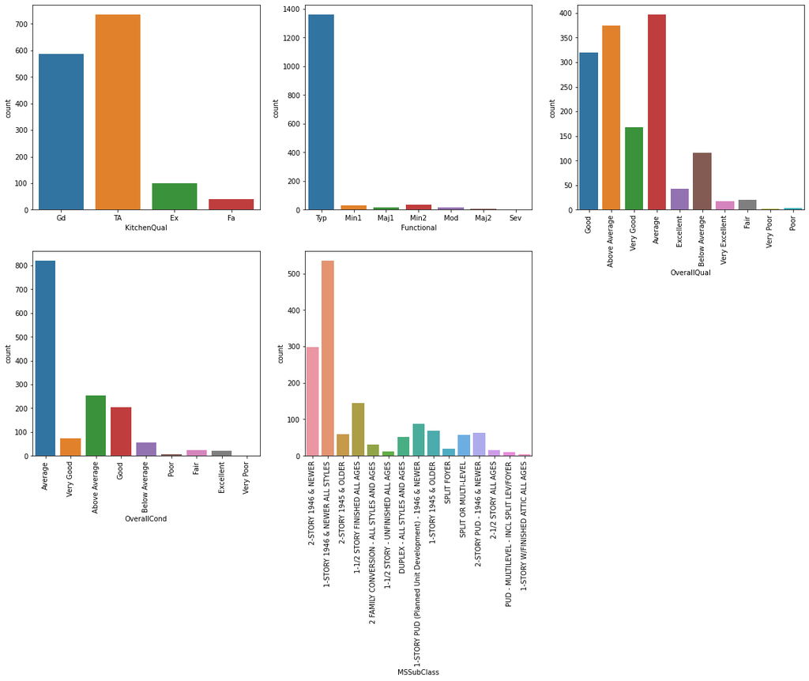

```python
plt.figure(figsize=(20, 12))
plt.subplot(2,3,1)
sns.countplot(x = 'KitchenQual',  data = house)
plt.subplot(2,3,2)
sns.countplot(x = 'Functional', data = house)
plt.subplot(2,3,3)
sns.countplot(x = 'OverallQual', data = house)
plt.xticks(rotation=90)
plt.subplot(2,3,4)
sns.countplot(x = 'OverallCond', data = house)
plt.xticks(rotation=90)

plt.subplot(2,3,5)
sns.countplot(x = 'MSSubClass',  data = house)
plt.xticks(rotation=90)


plt.show()
```

```python
house['MSSubClass'].value_counts() # similarly checking other columns for skewness
```

```
1-STORY 1946 & NEWER ALL STYLES                          536
2-STORY 1946 & NEWER                                     299
1-1/2 STORY FINISHED ALL AGES                            144
1-STORY PUD (Planned Unit Development) - 1946 & NEWER     87
1-STORY 1945 & OLDER                                      69
2-STORY PUD - 1946 & NEWER                                63
2-STORY 1945 & OLDER                                      60
SPLIT OR MULTI-LEVEL                                      58
DUPLEX - ALL STYLES AND AGES                              52
2 FAMILY CONVERSION - ALL STYLES AND AGES                 30
SPLIT FOYER                                               20
2-1/2 STORY ALL AGES                                      16
1-1/2 STORY - UNFINISHED ALL AGES                         12
PUD - MULTILEVEL - INCL SPLIT LEV/FOYER                   10
1-STORY W/FINISHED ATTIC ALL AGES                          4
Name: MSSubClass, dtype: int64
```

```python
# Dropping highly skewed column
house.drop(['Functional'],axis=1,inplace=True)
```

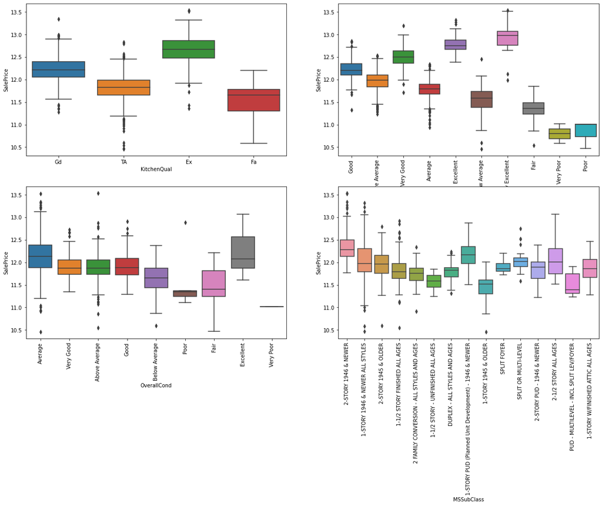

```python
plt.figure(figsize=(20, 12))
plt.subplot(2,2,1)
sns.boxplot(x ='KitchenQual', y ='SalePrice', data = house)
plt.subplot(2,2,2)
sns.boxplot(x = 'OverallQual', y = 'SalePrice', data = house)
plt.xticks(rotation=90)

plt.subplot(2,2,3)
sns.boxplot(x = 'OverallCond', y = 'SalePrice', data = house)
plt.xticks(rotation=90)

plt.subplot(2,2,4)
sns.boxplot(x = 'MSSubClass', y = 'SalePrice', data = house)
plt.xticks(rotation=90)

plt.show()
```

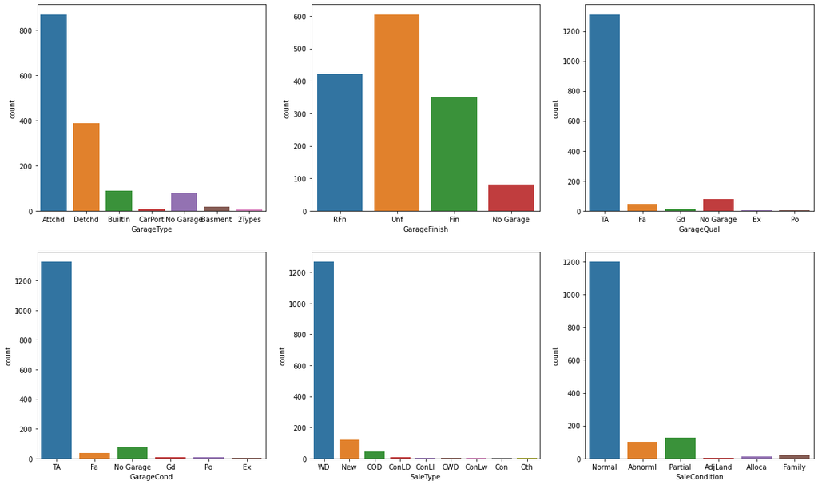

```python
plt.figure(figsize=(20, 12))
plt.subplot(2,3,1)
sns.countplot(x = 'GarageType',  data = house)
plt.subplot(2,3,2)
sns.countplot(x = 'GarageFinish', data = house)
plt.subplot(2,3,3)
sns.countplot(x = 'GarageQual', data = house)
plt.subplot(2,3,4)
sns.countplot(x = 'GarageCond', data = house)
plt.subplot(2,3,5)
sns.countplot(x = 'SaleType',  data = house)
plt.subplot(2,3,6)
sns.countplot(x = 'SaleCondition', data = house)
plt.show()
```

```python
house['SaleCondition'].value_counts() #similarly checking other columns for skewness
```

```
Normal     1198
Partial     125
Abnorml     101
Family       20
Alloca       12
AdjLand       4
Name: SaleCondition, dtype: int64
```

We can see that in this group except GarageType and Garage Finsih almost all are skewed so we can drop these columns

```python
house['GarageType'] = house['GarageType'].replace(['Basment','CarPort','2Types'],'Others')
house['SaleCondition'] = house['SaleCondition'].replace(['Family','Alloca','AdjLand'],'Others')



# Dropping highly skewed column
house.drop(['GarageQual','GarageCond','SaleType'],axis=1,inplace=True)
```

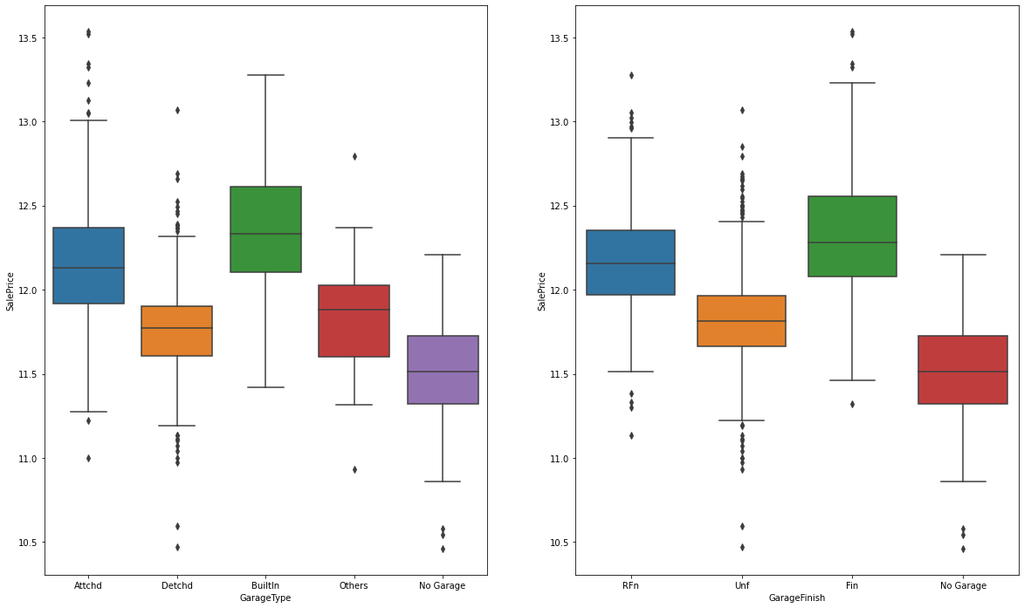

```python
#Let's see effect of Garage type and GarageFinish on SalePrice

plt.figure(figsize=(20, 12))
plt.subplot(1,2,1)
sns.boxplot(x = 'GarageType', y ='SalePrice', data = house)
plt.subplot(1,2,2)
sns.boxplot(x = 'GarageFinish', y = 'SalePrice', data = house)
```

Price of Builtin Garagetype and Finished garage is the highest

................................................................

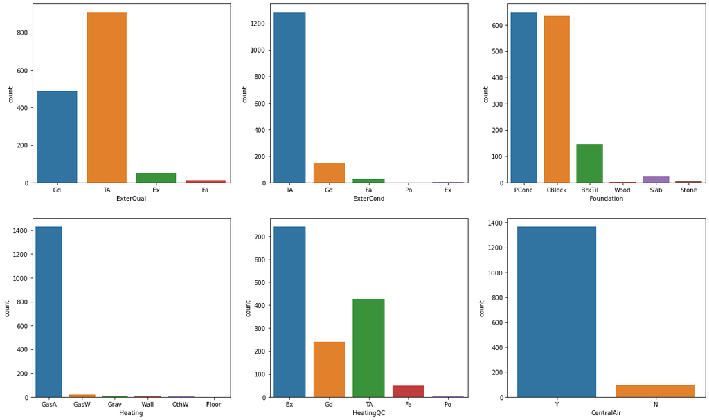

```python
plt.figure(figsize=(20, 12))
plt.subplot(2,3,1)
sns.countplot(x = 'ExterQual',  data = house)
plt.subplot(2,3,2)
sns.countplot(x = 'ExterCond', data = house)
plt.subplot(2,3,3)
sns.countplot(x = 'Foundation', data = house)
plt.subplot(2,3,4)
sns.countplot(x = 'Heating', data = house)
plt.subplot(2,3,5)
sns.countplot(x = 'HeatingQC',  data = house)
plt.subplot(2,3,6)
sns.countplot(x = 'CentralAir', data = house)
plt.show()
```

-Majority of ExterQual, ExerCond is TA

-Poured Contrete foundation are the highest in number

-Meanwhile variables like Heating , Central Airand Exter Cond are skewed so would be dropping these variables

```python
house['HeatingQC'].value_counts() # similarly checked for all variables to check the skewness
```

```
Ex    741
TA    428
Gd    241
Fa     49
Po      1
Name: HeatingQC, dtype: int64
```

```python
house['Foundation'] = house['Foundation'].replace(['Slab','Stone','Wood'],'Others')



# Dropping highly skewed column
house.drop(['CentralAir','Heating','ExterCond'],axis=1,inplace=True)
```

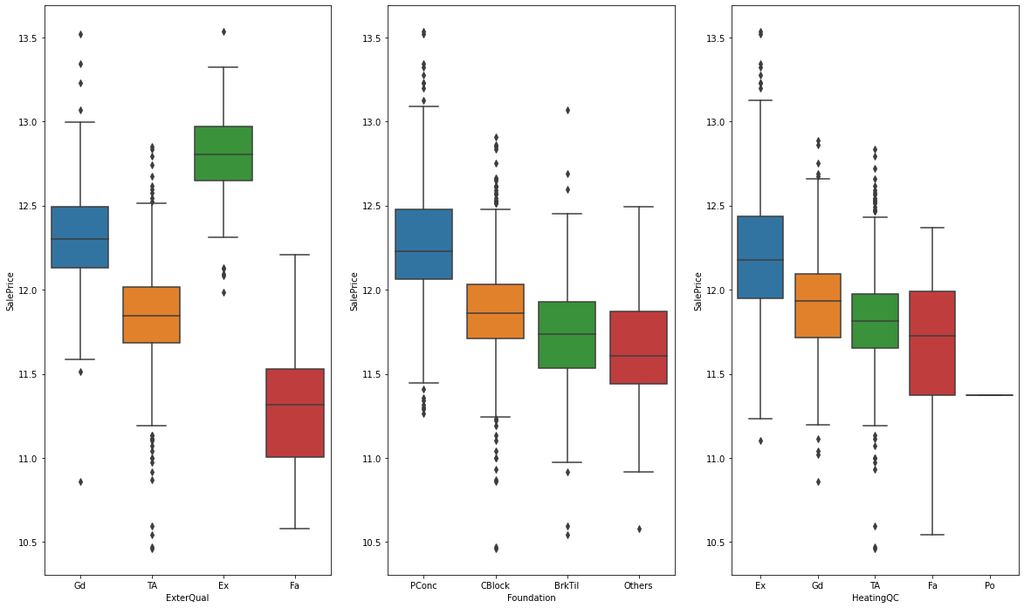

```python
#Let's see effect of Garage type and GarageFinish on SalePrice

plt.figure(figsize=(20, 12))
plt.subplot(1,3,1)
sns.boxplot(x = 'ExterQual', y ='SalePrice', data = house)
plt.subplot(1,3,2)
sns.boxplot(x = 'Foundation', y = 'SalePrice', data = house)
plt.subplot(1,3,3)
sns.boxplot(x = 'HeatingQC', y = 'SalePrice', data = house)
```

-Price of Excellent ExterQual and HeatingQc is highest

-Price of Poured Contrete Foundation is highest.

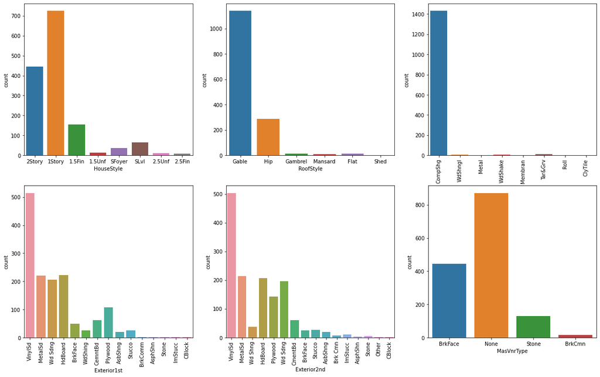

```python
plt.figure(figsize=(20, 12))
plt.subplot(2,3,1)
sns.countplot(x = 'HouseStyle',  data = house)
plt.subplot(2,3,2)
sns.countplot(x = 'RoofStyle', data = house)
plt.subplot(2,3,3)
sns.countplot(x = 'RoofMatl', data = house)
plt.xticks(rotation=90)
plt.subplot(2,3,4)
sns.countplot(x = 'Exterior1st', data = house)
plt.xticks(rotation=90)
plt.subplot(2,3,5)
sns.countplot(x = 'Exterior2nd',  data = house)
plt.xticks(rotation=90)
plt.subplot(2,3,6)
sns.countplot(x = 'MasVnrType', data = house)
plt.show()
```

```python
house['Exterior2nd'].value_counts() #similarly checking the skewness for other columns
```

```
VinylSd    504
MetalSd    214
HdBoard    207
Wd Sdng    197
Plywood    142
CmentBd     60
Wd Shng     38
Stucco      26
BrkFace     25
AsbShng     20
ImStucc     10
Brk Cmn      7
Stone        5
AsphShn      3
CBlock       1
Other        1
Name: Exterior2nd, dtype: int64
```

```python
house['HouseStyle'] = house['HouseStyle'].replace(['SFoyer','1.5Unf','2.5Unf','2.5Fin'],'Others')
house['RoofStyle'] = house['RoofStyle'].replace(['Shed','Mansard','Gambrel','Flat'],'Others')
house['Exterior1st'] = house['Exterior1st'].replace(['AsphShn','ImStucc','CBlock','Stone','BrkComm','AsbShng','Stucco','WdShing'],'Others')
house['Exterior2nd'] = house['Exterior2nd'].replace(['Other','AsphShn','ImStucc','CBlock','Stone','BrkComm','AsbShng','Stucco','BrkFace'],'Others')

# Dropping highly skewed column
house.drop(['RoofMatl'],axis=1,inplace=True)
```

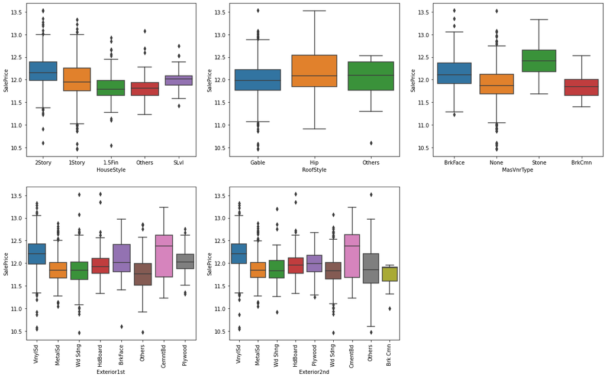

```python
plt.figure(figsize=(20, 12))
plt.subplot(2,3,1)
sns.boxplot(x = 'HouseStyle', y ='SalePrice', data = house)
plt.subplot(2,3,2)
sns.boxplot(x = 'RoofStyle', y = 'SalePrice', data = house)
plt.subplot(2,3,3)
sns.boxplot(x = 'MasVnrType', y = 'SalePrice', data = house)
plt.subplot(2,3,4)
sns.boxplot(x = 'Exterior1st', y = 'SalePrice', data = house)
plt.xticks(rotation=90)
plt.subplot(2,3,5)
sns.boxplot(x = 'Exterior2nd', y = 'SalePrice', data = house)
plt.xticks(rotation=90)
plt.show()
```

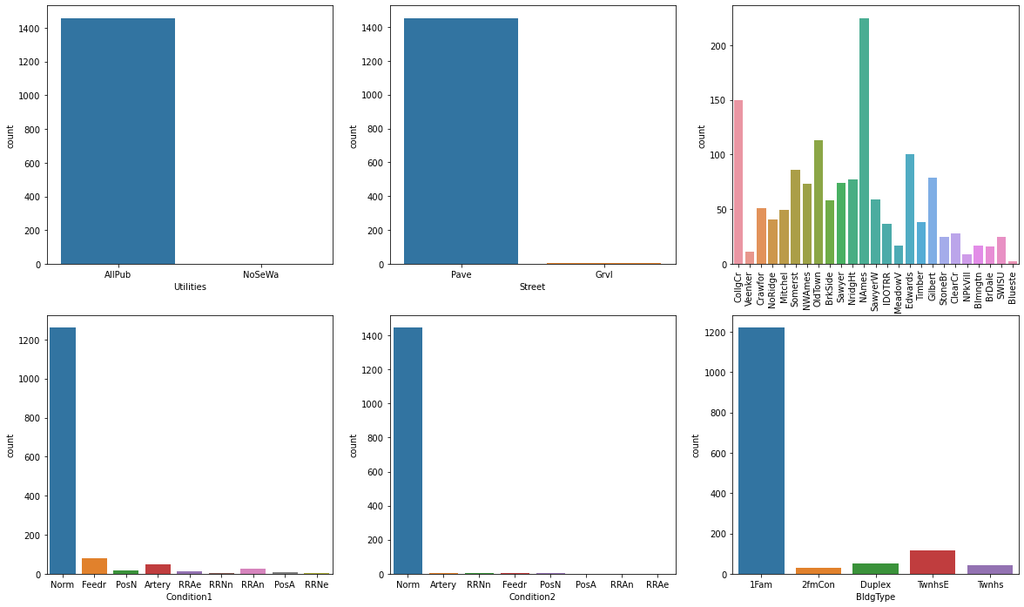

```python
plt.figure(figsize=(20, 12))
plt.subplot(2,3,1)
sns.countplot(x = 'Utilities',  data = house)
plt.subplot(2,3,2)
sns.countplot(x = 'Street', data = house)
plt.subplot(2,3,3)
sns.countplot(x = 'Neighborhood', data = house)
plt.xticks(rotation=90)
plt.subplot(2,3,4)
sns.countplot(x = 'Condition1', data = house)
plt.subplot(2,3,5)
sns.countplot(x = 'Condition2',  data = house)
plt.subplot(2,3,6)
sns.countplot(x = 'BldgType', data = house)
plt.show()
```

```python
house['BldgType'].value_counts()#similarly checking skewness for other columns
```

```
1Fam      1220
TwnhsE     114
Duplex      52
Twnhs       43
2fmCon      31
Name: BldgType, dtype: int64
```

```python
# Dropping highly skewed column
house.drop(['Utilities','Street','Condition1','Condition2'],axis=1,inplace=True)
```

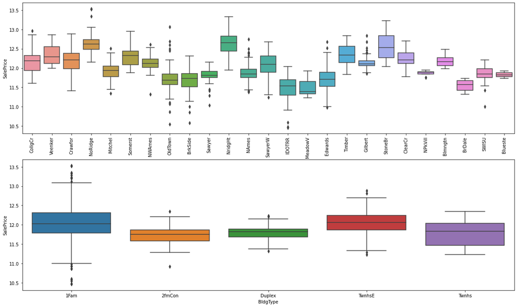

```python
plt.figure(figsize=(20, 12))
plt.subplot(2,1,1)
sns.boxplot(x = 'Neighborhood', y ='SalePrice', data = house)
plt.xticks(rotation=90)
plt.subplot(2,1,2)
sns.boxplot(x = 'BldgType', y = 'SalePrice', data = house)
```

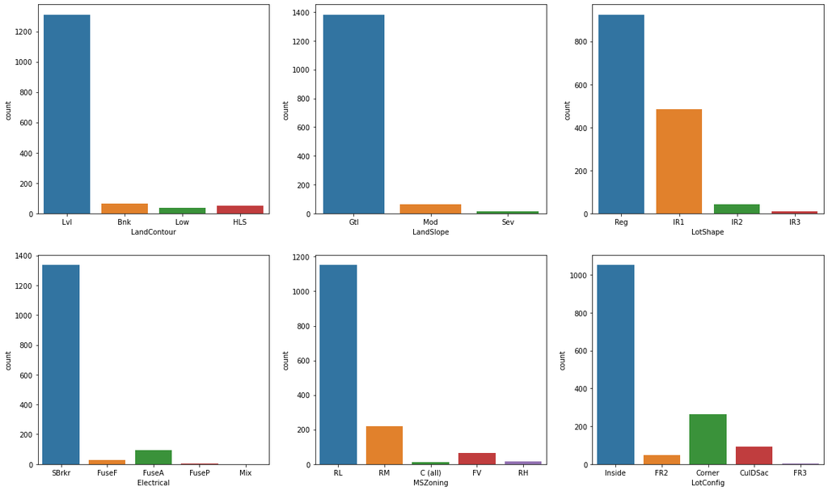

```python
plt.figure(figsize=(20, 12))
plt.subplot(2,3,1)
sns.countplot(x = 'LandContour',  data = house)
plt.subplot(2,3,2)
sns.countplot(x = 'LandSlope', data = house)
plt.subplot(2,3,3)
sns.countplot(x = 'LotShape', data = house)
plt.subplot(2,3,4)
sns.countplot(x = 'Electrical', data = house)
plt.subplot(2,3,5)
sns.countplot(x = 'MSZoning',  data = house)
plt.subplot(2,3,6)
sns.countplot(x = 'LotConfig', data = house)
plt.show()
```

```python
house['LotConfig'].value_counts()
```

```
Inside     1052
Corner      263
CulDSac      94
FR2          47
FR3           4
Name: LotConfig, dtype: int64
```

```python
house.drop(['LandSlope','LandContour','Electrical'],axis=1,inplace=True)

house['MSZoning'] = house['MSZoning'].replace(['RH','C (all)'],'Others')
```

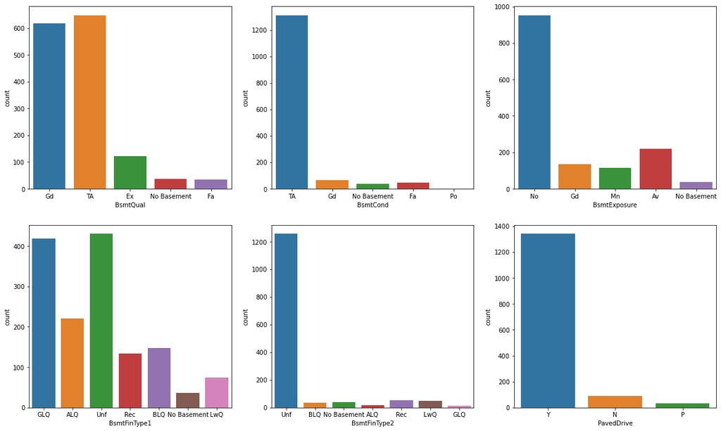

```python
plt.figure(figsize=(20, 12))
plt.subplot(2,3,1)
sns.countplot(x = 'BsmtQual',  data = house)
plt.subplot(2,3,2)
sns.countplot(x = 'BsmtCond', data = house)
plt.subplot(2,3,3)
sns.countplot(x = 'BsmtExposure', data = house)
plt.subplot(2,3,4)
sns.countplot(x = 'BsmtFinType1', data = house)
plt.subplot(2,3,5)
sns.countplot(x = 'BsmtFinType2',  data = house)
plt.subplot(2,3,6)
sns.countplot(x = 'PavedDrive', data = house)
plt.show()
```

```python
house['BsmtCond'].value_counts() # similarly checking skewness for other columns
```

```
TA             1311
Gd               65
Fa               45
No Basement      37
Po                2
Name: BsmtCond, dtype: int64
```

```python
house.drop(['BsmtFinType2','PavedDrive','BsmtCond'],axis=1,inplace=True)
```

```python
house.head()
```

|  | Id | MSSubClass | MSZoning | LotFrontage | LotArea | LotShape | LotConfig | Neighborhood | BldgType | HouseStyle | OverallQual | OverallCond | YearBuilt | YearRemodAdd | RoofStyle | Exterior1st | Exterior2nd | MasVnrType | MasVnrArea | ExterQual | Foundation | BsmtQual | BsmtExposure | BsmtFinType1 | BsmtFinSF1 | BsmtFinSF2 | BsmtUnfSF | TotalBsmtSF | HeatingQC | … |
| --- | --- | --- | --- | --- | --- | --- | --- | --- | --- | --- | --- | --- | --- | --- | --- | --- | --- | --- | --- | --- | --- | --- | --- | --- | --- | --- | --- | --- | --- | --- |
| 0 | 1 | 2-STORY 1946 & NEWER | RL | 65.0 | 8450 | Reg | Inside | CollgCr | 1Fam | 2Story | Good | Average | 2003 | 2003 | Gable | VinylSd | VinylSd | BrkFace | 196.0 | Gd | PConc | Gd | No | GLQ | 706 | 0 | 150 | 856 | Ex | … |
| 1 | 2 | 1-STORY 1946 & NEWER ALL STYLES | RL | 80.0 | 9600 | Reg | FR2 | Veenker | 1Fam | 1Story | Above Average | Very Good | 1976 | 1976 | Gable | MetalSd | MetalSd | None | 0.0 | TA | CBlock | Gd | Gd | ALQ | 978 | 0 | 284 | 1262 | Ex | … |
| 2 | 3 | 2-STORY 1946 & NEWER | RL | 68.0 | 11250 | IR1 | Inside | CollgCr | 1Fam | 2Story | Good | Average | 2001 | 2002 | Gable | VinylSd | VinylSd | BrkFace | 162.0 | Gd | PConc | Gd | Mn | GLQ | 486 | 0 | 434 | 920 | Ex | … |
| 3 | 4 | 2-STORY 1945 & OLDER | RL | 60.0 | 9550 | IR1 | Corner | Crawfor | 1Fam | 2Story | Good | Average | 1915 | 1970 | Gable | Wd Sdng | Wd Shng | None | 0.0 | TA | BrkTil | TA | No | ALQ | 216 | 0 | 540 | 756 | Gd | … |
| 4 | 5 | 2-STORY 1946 & NEWER | RL | 84.0 | 14260 | IR1 | FR2 | NoRidge | 1Fam | 2Story | Very Good | Average | 2000 | 2000 | Gable | VinylSd | VinylSd | BrkFace | 350.0 | Gd | PConc | Gd | Av | GLQ | 655 | 0 | 490 | 1145 | Ex | … |

```python
house.info()
```

```
<class 'pandas.core.frame.DataFrame'>
RangeIndex: 1460 entries, 0 to 1459
Data columns (total 58 columns):
 #   Column         Non-Null Count  Dtype
---  ------         --------------  -----
 0   Id             1460 non-null   int64
 1   MSSubClass     1460 non-null   object
 2   MSZoning       1460 non-null   object
 3   LotFrontage    1460 non-null   float64
 4   LotArea        1460 non-null   int64
 5   LotShape       1460 non-null   object
 6   LotConfig      1460 non-null   object
 7   Neighborhood   1460 non-null   object
 8   BldgType       1460 non-null   object
 9   HouseStyle     1460 non-null   object
```

[output cut: 50 more lines]

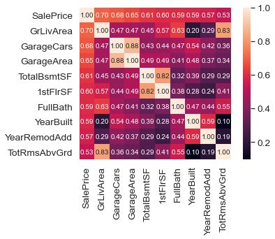

```python
#saleprice correlation matrix
corrmat = house.corr()
k = 10 #number of variables for heatmap
cols = corrmat.nlargest(k, 'SalePrice')['SalePrice'].index
cm = np.corrcoef(house[cols].values.T)
sns.set(font_scale=1.25)
hm = sns.heatmap(cm, cbar=True, annot=True, square=True, fmt='.2f', annot_kws={'size': 10}, yticklabels=cols.values, xticklabels=cols.values)
plt.show()
```

```python
house['YearSinceRemodel'] = 2010 - ((house['YearRemodAdd'] - house['YearBuilt']) + house['YearBuilt']) #feature engineering
```

```python
Cat1 = house.select_dtypes(include=['object']) #checking all categorical columns to form dummy variables
Cat1.columns
```

```
Index(['MSSubClass', 'MSZoning', 'LotShape', 'LotConfig', 'Neighborhood',
       'BldgType', 'HouseStyle', 'OverallQual', 'OverallCond', 'RoofStyle',
       'Exterior1st', 'Exterior2nd', 'MasVnrType', 'ExterQual', 'Foundation',
       'BsmtQual', 'BsmtExposure', 'BsmtFinType1', 'HeatingQC', 'KitchenQual',
       'GarageType', 'GarageFinish', 'SaleCondition'],
      dtype='object')
```

```python
Num = house.select_dtypes(include=['int64','float64']) #all numerical variables
Num.columns
```

```
Index(['Id', 'LotFrontage', 'LotArea', 'YearBuilt', 'YearRemodAdd',
       'MasVnrArea', 'BsmtFinSF1', 'BsmtFinSF2', 'BsmtUnfSF', 'TotalBsmtSF',
       '1stFlrSF', '2ndFlrSF', 'LowQualFinSF', 'GrLivArea', 'BsmtFullBath',
       'BsmtHalfBath', 'FullBath', 'HalfBath', 'BedroomAbvGr', 'KitchenAbvGr',
       'TotRmsAbvGrd', 'Fireplaces', 'GarageYrBlt', 'GarageCars', 'GarageArea',
       'WoodDeckSF', 'OpenPorchSF', 'EnclosedPorch', '3SsnPorch',
       'ScreenPorch', 'PoolArea', 'MiscVal', 'MoSold', 'YrSold', 'SalePrice',
       'YearSinceRemodel'],
      dtype='object')
```

```python
Num.info()
```

```
<class 'pandas.core.frame.DataFrame'>
RangeIndex: 1460 entries, 0 to 1459
Data columns (total 36 columns):
 #   Column            Non-Null Count  Dtype
---  ------            --------------  -----
 0   Id                1460 non-null   int64
 1   LotFrontage       1460 non-null   float64
 2   LotArea           1460 non-null   int64
 3   YearBuilt         1460 non-null   int64
 4   YearRemodAdd      1460 non-null   int64
 5   MasVnrArea        1460 non-null   float64
 6   BsmtFinSF1        1460 non-null   int64
 7   BsmtFinSF2        1460 non-null   int64
 8   BsmtUnfSF         1460 non-null   int64
 9   TotalBsmtSF       1460 non-null   int64
```

[output cut: 28 more lines]

```python
Cat1 = pd.get_dummies(Cat1,drop_first=True)  # Dummy variables
print(Cat1.shape)
```

```
(1460, 130)
```

```python
Cat1.head()
```

|  | MSSubClass_1-1/2 STORY FINISHED ALL AGES | MSSubClass_1-STORY 1945 & OLDER | MSSubClass_1-STORY 1946 & NEWER ALL STYLES | MSSubClass_1-STORY PUD (Planned Unit Development) - 1946 & NEWER | MSSubClass_1-STORY W/FINISHED ATTIC ALL AGES | MSSubClass_2 FAMILY CONVERSION - ALL STYLES AND AGES | MSSubClass_2-1/2 STORY ALL AGES | MSSubClass_2-STORY 1945 & OLDER | MSSubClass_2-STORY 1946 & NEWER | MSSubClass_2-STORY PUD - 1946 & NEWER | MSSubClass_DUPLEX - ALL STYLES AND AGES | MSSubClass_PUD - MULTILEVEL - INCL SPLIT LEV/FOYER | MSSubClass_SPLIT FOYER | MSSubClass_SPLIT OR MULTI-LEVEL | MSZoning_Others | MSZoning_RL | MSZoning_RM | LotShape_IR2 | LotShape_IR3 | LotShape_Reg | LotConfig_CulDSac | LotConfig_FR2 | LotConfig_FR3 | LotConfig_Inside | Neighborhood_Blueste | Neighborhood_BrDale | Neighborhood_BrkSide | Neighborhood_ClearCr | Neighborhood_CollgCr | … |
| --- | --- | --- | --- | --- | --- | --- | --- | --- | --- | --- | --- | --- | --- | --- | --- | --- | --- | --- | --- | --- | --- | --- | --- | --- | --- | --- | --- | --- | --- | --- |
| 0 | 0 | 0 | 0 | 0 | 0 | 0 | 0 | 0 | 1 | 0 | 0 | 0 | 0 | 0 | 0 | 1 | 0 | 0 | 0 | 1 | 0 | 0 | 0 | 1 | 0 | 0 | 0 | 0 | 1 | … |
| 1 | 0 | 0 | 1 | 0 | 0 | 0 | 0 | 0 | 0 | 0 | 0 | 0 | 0 | 0 | 0 | 1 | 0 | 0 | 0 | 1 | 0 | 1 | 0 | 0 | 0 | 0 | 0 | 0 | 0 | … |
| 2 | 0 | 0 | 0 | 0 | 0 | 0 | 0 | 0 | 1 | 0 | 0 | 0 | 0 | 0 | 0 | 1 | 0 | 0 | 0 | 0 | 0 | 0 | 0 | 1 | 0 | 0 | 0 | 0 | 1 | … |
| 3 | 0 | 0 | 0 | 0 | 0 | 0 | 0 | 1 | 0 | 0 | 0 | 0 | 0 | 0 | 0 | 1 | 0 | 0 | 0 | 0 | 0 | 0 | 0 | 0 | 0 | 0 | 0 | 0 | 0 | … |
| 4 | 0 | 0 | 0 | 0 | 0 | 0 | 0 | 0 | 1 | 0 | 0 | 0 | 0 | 0 | 0 | 1 | 0 | 0 | 0 | 0 | 0 | 1 | 0 | 0 | 0 | 0 | 0 | 0 | 0 | … |

5 rows × 130 columns

```python
# concat dummy variables with main dataset
house = pd.concat([house, Cat1], axis=1)
```

```python
house.head()
```

|  | Id | MSSubClass | MSZoning | LotFrontage | LotArea | LotShape | LotConfig | Neighborhood | BldgType | HouseStyle | OverallQual | OverallCond | YearBuilt | YearRemodAdd | RoofStyle | Exterior1st | Exterior2nd | MasVnrType | MasVnrArea | ExterQual | Foundation | BsmtQual | BsmtExposure | BsmtFinType1 | BsmtFinSF1 | BsmtFinSF2 | BsmtUnfSF | TotalBsmtSF | HeatingQC | … |
| --- | --- | --- | --- | --- | --- | --- | --- | --- | --- | --- | --- | --- | --- | --- | --- | --- | --- | --- | --- | --- | --- | --- | --- | --- | --- | --- | --- | --- | --- | --- |
| 0 | 1 | 2-STORY 1946 & NEWER | RL | 65.0 | 8450 | Reg | Inside | CollgCr | 1Fam | 2Story | Good | Average | 2003 | 2003 | Gable | VinylSd | VinylSd | BrkFace | 196.0 | Gd | PConc | Gd | No | GLQ | 706 | 0 | 150 | 856 | Ex | … |
| 1 | 2 | 1-STORY 1946 & NEWER ALL STYLES | RL | 80.0 | 9600 | Reg | FR2 | Veenker | 1Fam | 1Story | Above Average | Very Good | 1976 | 1976 | Gable | MetalSd | MetalSd | None | 0.0 | TA | CBlock | Gd | Gd | ALQ | 978 | 0 | 284 | 1262 | Ex | … |
| 2 | 3 | 2-STORY 1946 & NEWER | RL | 68.0 | 11250 | IR1 | Inside | CollgCr | 1Fam | 2Story | Good | Average | 2001 | 2002 | Gable | VinylSd | VinylSd | BrkFace | 162.0 | Gd | PConc | Gd | Mn | GLQ | 486 | 0 | 434 | 920 | Ex | … |
| 3 | 4 | 2-STORY 1945 & OLDER | RL | 60.0 | 9550 | IR1 | Corner | Crawfor | 1Fam | 2Story | Good | Average | 1915 | 1970 | Gable | Wd Sdng | Wd Shng | None | 0.0 | TA | BrkTil | TA | No | ALQ | 216 | 0 | 540 | 756 | Gd | … |
| 4 | 5 | 2-STORY 1946 & NEWER | RL | 84.0 | 14260 | IR1 | FR2 | NoRidge | 1Fam | 2Story | Very Good | Average | 2000 | 2000 | Gable | VinylSd | VinylSd | BrkFace | 350.0 | Gd | PConc | Gd | Av | GLQ | 655 | 0 | 490 | 1145 | Ex | … |

5 rows × 189 columns

```python
house.drop(['MSZoning', 'LotShape', 'LotConfig', 'Neighborhood', 'BldgType',
       'HouseStyle', 'RoofStyle', 'Exterior1st', 'Exterior2nd', 'MasVnrType',
       'ExterQual', 'Foundation', 'BsmtQual', 'BsmtExposure', 'BsmtFinType1',
       'HeatingQC', 'KitchenQual', 'GarageType', 'GarageFinish',
       'SaleCondition','Id','OverallCond','MSSubClass','OverallQual'],axis=1,inplace=True) #removing columns as dummy variables already formed
```

```python
house.head()
```

|  | LotFrontage | LotArea | YearBuilt | YearRemodAdd | MasVnrArea | BsmtFinSF1 | BsmtFinSF2 | BsmtUnfSF | TotalBsmtSF | 1stFlrSF | 2ndFlrSF | LowQualFinSF | GrLivArea | BsmtFullBath | BsmtHalfBath | FullBath | HalfBath | BedroomAbvGr | KitchenAbvGr | TotRmsAbvGrd | Fireplaces | GarageYrBlt | GarageCars | GarageArea | WoodDeckSF | OpenPorchSF | EnclosedPorch | 3SsnPorch | ScreenPorch | … |
| --- | --- | --- | --- | --- | --- | --- | --- | --- | --- | --- | --- | --- | --- | --- | --- | --- | --- | --- | --- | --- | --- | --- | --- | --- | --- | --- | --- | --- | --- | --- |
| 0 | 65.0 | 8450 | 2003 | 2003 | 196.0 | 706 | 0 | 150 | 856 | 856 | 854 | 0 | 1710 | 1 | 0 | 2 | 1 | 3 | 1 | 8 | 0 | 2003.0 | 2 | 548 | 0 | 61 | 0 | 0 | 0 | … |
| 1 | 80.0 | 9600 | 1976 | 1976 | 0.0 | 978 | 0 | 284 | 1262 | 1262 | 0 | 0 | 1262 | 0 | 1 | 2 | 0 | 3 | 1 | 6 | 1 | 1976.0 | 2 | 460 | 298 | 0 | 0 | 0 | 0 | … |
| 2 | 68.0 | 11250 | 2001 | 2002 | 162.0 | 486 | 0 | 434 | 920 | 920 | 866 | 0 | 1786 | 1 | 0 | 2 | 1 | 3 | 1 | 6 | 1 | 2001.0 | 2 | 608 | 0 | 42 | 0 | 0 | 0 | … |
| 3 | 60.0 | 9550 | 1915 | 1970 | 0.0 | 216 | 0 | 540 | 756 | 961 | 756 | 0 | 1717 | 1 | 0 | 1 | 0 | 3 | 1 | 7 | 1 | 1998.0 | 3 | 642 | 0 | 35 | 272 | 0 | 0 | … |
| 4 | 84.0 | 14260 | 2000 | 2000 | 350.0 | 655 | 0 | 490 | 1145 | 1145 | 1053 | 0 | 2198 | 1 | 0 | 2 | 1 | 4 | 1 | 9 | 1 | 2000.0 | 3 | 836 | 192 | 84 | 0 | 0 | 0 | … |

5 rows × 165 columns

```python
house.drop(['YearBuilt','YearRemodAdd','GarageYrBlt','YrSold'],axis=1,inplace=True) #no need of these while making a model
```

```python
house.head()
```

|  | LotFrontage | LotArea | MasVnrArea | BsmtFinSF1 | BsmtFinSF2 | BsmtUnfSF | TotalBsmtSF | 1stFlrSF | 2ndFlrSF | LowQualFinSF | GrLivArea | BsmtFullBath | BsmtHalfBath | FullBath | HalfBath | BedroomAbvGr | KitchenAbvGr | TotRmsAbvGrd | Fireplaces | GarageCars | GarageArea | WoodDeckSF | OpenPorchSF | EnclosedPorch | 3SsnPorch | ScreenPorch | PoolArea | MiscVal | MoSold | … |
| --- | --- | --- | --- | --- | --- | --- | --- | --- | --- | --- | --- | --- | --- | --- | --- | --- | --- | --- | --- | --- | --- | --- | --- | --- | --- | --- | --- | --- | --- | --- |
| 0 | 65.0 | 8450 | 196.0 | 706 | 0 | 150 | 856 | 856 | 854 | 0 | 1710 | 1 | 0 | 2 | 1 | 3 | 1 | 8 | 0 | 2 | 548 | 0 | 61 | 0 | 0 | 0 | 0 | 0 | 2 | … |
| 1 | 80.0 | 9600 | 0.0 | 978 | 0 | 284 | 1262 | 1262 | 0 | 0 | 1262 | 0 | 1 | 2 | 0 | 3 | 1 | 6 | 1 | 2 | 460 | 298 | 0 | 0 | 0 | 0 | 0 | 0 | 5 | … |
| 2 | 68.0 | 11250 | 162.0 | 486 | 0 | 434 | 920 | 920 | 866 | 0 | 1786 | 1 | 0 | 2 | 1 | 3 | 1 | 6 | 1 | 2 | 608 | 0 | 42 | 0 | 0 | 0 | 0 | 0 | 9 | … |
| 3 | 60.0 | 9550 | 0.0 | 216 | 0 | 540 | 756 | 961 | 756 | 0 | 1717 | 1 | 0 | 1 | 0 | 3 | 1 | 7 | 1 | 3 | 642 | 0 | 35 | 272 | 0 | 0 | 0 | 0 | 2 | … |
| 4 | 84.0 | 14260 | 350.0 | 655 | 0 | 490 | 1145 | 1145 | 1053 | 0 | 2198 | 1 | 0 | 2 | 1 | 4 | 1 | 9 | 1 | 3 | 836 | 192 | 84 | 0 | 0 | 0 | 0 | 0 | 12 | … |

5 rows × 161 columns

```python
# Putting feature variable to X
X = house.drop(['SalePrice'], axis=1)

X.head()
```

|  | LotFrontage | LotArea | MasVnrArea | BsmtFinSF1 | BsmtFinSF2 | BsmtUnfSF | TotalBsmtSF | 1stFlrSF | 2ndFlrSF | LowQualFinSF | GrLivArea | BsmtFullBath | BsmtHalfBath | FullBath | HalfBath | BedroomAbvGr | KitchenAbvGr | TotRmsAbvGrd | Fireplaces | GarageCars | GarageArea | WoodDeckSF | OpenPorchSF | EnclosedPorch | 3SsnPorch | ScreenPorch | PoolArea | MiscVal | MoSold | … |
| --- | --- | --- | --- | --- | --- | --- | --- | --- | --- | --- | --- | --- | --- | --- | --- | --- | --- | --- | --- | --- | --- | --- | --- | --- | --- | --- | --- | --- | --- | --- |
| 0 | 65.0 | 8450 | 196.0 | 706 | 0 | 150 | 856 | 856 | 854 | 0 | 1710 | 1 | 0 | 2 | 1 | 3 | 1 | 8 | 0 | 2 | 548 | 0 | 61 | 0 | 0 | 0 | 0 | 0 | 2 | … |
| 1 | 80.0 | 9600 | 0.0 | 978 | 0 | 284 | 1262 | 1262 | 0 | 0 | 1262 | 0 | 1 | 2 | 0 | 3 | 1 | 6 | 1 | 2 | 460 | 298 | 0 | 0 | 0 | 0 | 0 | 0 | 5 | … |
| 2 | 68.0 | 11250 | 162.0 | 486 | 0 | 434 | 920 | 920 | 866 | 0 | 1786 | 1 | 0 | 2 | 1 | 3 | 1 | 6 | 1 | 2 | 608 | 0 | 42 | 0 | 0 | 0 | 0 | 0 | 9 | … |
| 3 | 60.0 | 9550 | 0.0 | 216 | 0 | 540 | 756 | 961 | 756 | 0 | 1717 | 1 | 0 | 1 | 0 | 3 | 1 | 7 | 1 | 3 | 642 | 0 | 35 | 272 | 0 | 0 | 0 | 0 | 2 | … |
| 4 | 84.0 | 14260 | 350.0 | 655 | 0 | 490 | 1145 | 1145 | 1053 | 0 | 2198 | 1 | 0 | 2 | 1 | 4 | 1 | 9 | 1 | 3 | 836 | 192 | 84 | 0 | 0 | 0 | 0 | 0 | 12 | … |

5 rows × 160 columns

```python
# Putting response variable to y
y = house['SalePrice']

y.head()
```

```
0    12.247694
1    12.109011
2    12.317167
3    11.849398
4    12.429216
Name: SalePrice, dtype: float64
```

```python
X_train, X_test, y_train, y_test = train_test_split(X, y,
                                                    train_size=0.7,
                                                    test_size = 0.3, random_state=100)
```

```python
scaler = StandardScaler()

X_train[['LotFrontage', 'LotArea','MasVnrArea', 'BsmtFinSF1', 'BsmtFinSF2', 'BsmtUnfSF', 'TotalBsmtSF',
       '1stFlrSF', '2ndFlrSF', 'LowQualFinSF', 'GrLivArea', 'BsmtFullBath',
       'BsmtHalfBath', 'FullBath', 'HalfBath', 'BedroomAbvGr', 'KitchenAbvGr',
       'TotRmsAbvGrd', 'Fireplaces','GarageCars', 'GarageArea',
       'WoodDeckSF', 'OpenPorchSF', 'EnclosedPorch', '3SsnPorch',
       'ScreenPorch', 'PoolArea', 'MiscVal']] = scaler.fit_transform(X_train[['LotFrontage', 'LotArea','MasVnrArea', 'BsmtFinSF1', 'BsmtFinSF2', 'BsmtUnfSF', 'TotalBsmtSF',
       '1stFlrSF', '2ndFlrSF', 'LowQualFinSF', 'GrLivArea', 'BsmtFullBath',
       'BsmtHalfBath', 'FullBath', 'HalfBath', 'BedroomAbvGr', 'KitchenAbvGr',
       'TotRmsAbvGrd', 'Fireplaces','GarageCars', 'GarageArea',
       'WoodDeckSF', 'OpenPorchSF', 'EnclosedPorch', '3SsnPorch',
       'ScreenPorch', 'PoolArea', 'MiscVal']])

X_train.head()
```

|  | LotFrontage | LotArea | MasVnrArea | BsmtFinSF1 | BsmtFinSF2 | BsmtUnfSF | TotalBsmtSF | 1stFlrSF | 2ndFlrSF | LowQualFinSF | GrLivArea | BsmtFullBath | BsmtHalfBath | FullBath | HalfBath | BedroomAbvGr | KitchenAbvGr | TotRmsAbvGrd | Fireplaces | GarageCars | GarageArea | WoodDeckSF | OpenPorchSF | EnclosedPorch | 3SsnPorch | ScreenPorch | PoolArea | MiscVal | MoSold | … |
| --- | --- | --- | --- | --- | --- | --- | --- | --- | --- | --- | --- | --- | --- | --- | --- | --- | --- | --- | --- | --- | --- | --- | --- | --- | --- | --- | --- | --- | --- | --- |
| 210 | -0.115302 | -0.473765 | -0.558025 | 0.043512 | -0.293313 | -0.374367 | -0.430911 | -0.765065 | -0.787597 | -0.124502 | -1.228053 | 1.066863 | -0.247791 | -1.026085 | -0.751723 | -1.042717 | -0.234155 | -0.935650 | -0.925422 | -2.366798 | -2.217786 | -0.743160 | -0.709347 | 1.150231 | -0.121922 | -0.275126 | -0.062302 | -0.084263 | 4 | … |
| 318 | 0.926898 | -0.056845 | 0.809137 | 1.160345 | -0.293313 | -0.454644 | 0.621579 | 0.511914 | 2.140556 | -0.124502 | 2.123103 | 1.066863 | -0.247791 | 0.786428 | 1.246998 | 1.396261 | -0.234155 | 1.556976 | 0.623522 | 1.645101 | 0.867506 | 1.989482 | 0.197980 | 1.910043 | -0.121922 | -0.275126 | -0.062302 | -0.084263 | 4 | … |
| 239 | -0.794998 | -0.169324 | -0.558025 | -0.761296 | -0.293313 | 0.171964 | -0.712011 | -0.930972 | 0.795996 | -0.124502 | -0.056465 | -0.837450 | -0.247791 | -1.026085 | 1.246998 | 0.176772 | -0.234155 | 0.310663 | 0.623522 | -1.029498 | -1.183084 | -0.743160 | 1.407748 | -0.369395 | -0.121922 | -0.275126 | -0.062302 | -0.084263 | 4 | … |
| 986 | -0.477806 | -0.502297 | -0.558025 | -0.963574 | -0.293313 | -0.175904 | -1.256778 | -0.420683 | 0.669584 | -0.124502 | 0.221858 | -0.837450 | -0.247791 | -1.026085 | -0.751723 | -1.042717 | -0.234155 | -0.935650 | -0.925422 | -1.029498 | -1.018473 | 2.423490 | -0.709347 | -0.369395 | -0.121922 | -0.275126 | -0.062302 | -0.084263 | 6 | … |
| 1416 | -0.432493 | 0.082905 | -0.558025 | -0.963574 | -0.293313 | 0.475233 | -0.620490 | 0.195183 | 1.611926 | -0.124502 | 1.453624 | -0.837450 | -0.247791 | 0.786428 | -0.751723 | 1.396261 | 4.112612 | 2.803289 | -0.925422 | 0.307802 | 0.416000 | -0.743160 | -0.709347 | 1.435160 | -0.121922 | -0.275126 | -0.062302 | -0.084263 | 4 | … |

5 rows × 160 columns

```python
X_train, X_test, y_train, y_test = train_test_split(X, y,
                                                    train_size=0.7,
                                                    test_size = 0.3, random_state=100)
```

## Model Building and Evaluation

### Ridge and Lasso Regression

#### Ridge

```python
# list of alphas to tune
params = {'alpha': [0.00004,0.0001, 0.001, 0.01, 0.1, 10,100,1000]}


ridge = Ridge()

# cross validation
folds = 5
model_cv = GridSearchCV(estimator = ridge,
                        param_grid = params,
                        scoring= 'r2',
                        cv = folds,
                        return_train_score=True,
                        verbose = 1)
model_cv.fit(X_train, y_train)
```

```
Fitting 5 folds for each of 8 candidates, totalling 40 fits
```

```
[Parallel(n_jobs=1)]: Using backend SequentialBackend with 1 concurrent workers.
[Parallel(n_jobs=1)]: Done  40 out of  40 | elapsed:    2.2s finished
```

```
GridSearchCV(cv=5, estimator=Ridge(),
             param_grid={'alpha': [4e-05, 0.0001, 0.001, 0.01, 0.1, 10, 100,
                                   1000]},
             return_train_score=True, scoring='r2', verbose=1)
```

```python
cv_results = pd.DataFrame(model_cv.cv_results_)
cv_results = cv_results[cv_results['param_alpha']<=100]
cv_results.head()
```

|  | mean_fit_time | std_fit_time | mean_score_time | std_score_time | param_alpha | params | split0_test_score | split1_test_score | split2_test_score | split3_test_score | split4_test_score | mean_test_score | std_test_score | rank_test_score | split0_train_score | split1_train_score | split2_train_score | split3_train_score | split4_train_score | mean_train_score | std_train_score |
| --- | --- | --- | --- | --- | --- | --- | --- | --- | --- | --- | --- | --- | --- | --- | --- | --- | --- | --- | --- | --- | --- |
| 0 | 0.244188 | 4.649749e-01 | 0.015622 | 0.017116 | 4e-05 | {'alpha': 4e-05} | 0.868246 | 0.777081 | 0.838201 | 0.890474 | 0.892432 | 0.853287 | 0.042834 | 5 | 0.924369 | 0.935767 | 0.931027 | 0.919954 | 0.918905 | 0.926004 | 0.006484 |
| 1 | 0.013381 | 6.904067e-03 | 0.007142 | 0.007112 | 0.0001 | {'alpha': 0.0001} | 0.868247 | 0.777081 | 0.838201 | 0.890476 | 0.892436 | 0.853288 | 0.042836 | 4 | 0.924369 | 0.935767 | 0.931027 | 0.919954 | 0.918905 | 0.926004 | 0.006484 |
| 2 | 0.018748 | 6.249857e-03 | 0.003125 | 0.006250 | 0.001 | {'alpha': 0.001} | 0.868258 | 0.777072 | 0.838200 | 0.890516 | 0.892499 | 0.853309 | 0.042858 | 3 | 0.924369 | 0.935767 | 0.931027 | 0.919954 | 0.918905 | 0.926004 | 0.006484 |
| 3 | 0.015624 | 6.975526e-07 | 0.000000 | 0.000000 | 0.01 | {'alpha': 0.01} | 0.868367 | 0.776981 | 0.838188 | 0.890866 | 0.893107 | 0.853502 | 0.043071 | 2 | 0.924368 | 0.935766 | 0.931026 | 0.919953 | 0.918902 | 0.926003 | 0.006484 |
| 4 | 0.018748 | 6.251598e-03 | 0.003126 | 0.006251 | 0.1 | {'alpha': 0.1} | 0.869382 | 0.776055 | 0.838034 | 0.892791 | 0.897577 | 0.854768 | 0.044649 | 1 | 0.924329 | 0.935711 | 0.930967 | 0.919904 | 0.918744 | 0.925931 | 0.006505 |

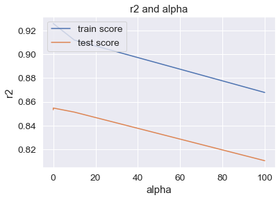

```python
# plotting mean test and train scoes with alpha
cv_results['param_alpha'] = cv_results['param_alpha'].astype('int32')

# plotting
plt.plot(cv_results['param_alpha'], cv_results['mean_train_score'])
plt.plot(cv_results['param_alpha'], cv_results['mean_test_score'])
plt.xlabel('alpha')
plt.ylabel('r2')
plt.title("r2 and alpha")
plt.legend(['train score', 'test score'], loc='upper left')
plt.show()
```

```python
#optimum alpha

alpha = 10
ridge = Ridge(alpha=alpha)

ridge.fit(X_train, y_train)
ridge.coef_
```

```
array([-4.74809780e-04,  1.59466646e-06,  6.17112057e-06,  3.73538380e-06,
        1.15081413e-05,  1.82053032e-05,  3.34488391e-05,  7.92009064e-05,
        1.09011748e-04, -7.70408601e-05,  1.11171805e-04,  4.25420135e-02,
        1.51319614e-02,  5.09516505e-02,  3.69272171e-02,  9.07794039e-03,
       -8.12648652e-02,  8.30696546e-03,  3.96097675e-02,  5.34751466e-02,
        3.43279188e-05,  9.90267283e-05, -5.47707192e-05,  1.22380757e-04,
        1.94886076e-04,  2.27453067e-04, -4.04142867e-04, -3.68907754e-06,
        5.21312292e-04, -1.59513446e-03,  1.22746032e-02, -8.43053932e-02,
        4.98263439e-02,  5.96932189e-03,  1.37128949e-04, -1.20780328e-02,
        2.35023365e-02,  2.51877006e-02, -1.48351396e-05, -4.06689958e-02,
        1.48370219e-02, -2.89980792e-02,  2.13765700e-02,  9.23512984e-03,
       -7.75969900e-02,  1.25978119e-02, -2.93034632e-02,  2.18691748e-02,
       -4.94699235e-02,  7.41424037e-03,  3.66405387e-02, -3.24003086e-02,
       -1.39715714e-02, -3.40987853e-03, -2.21542138e-03, -1.30144969e-02,
        2.02737767e-02,  4.27356892e-02, -8.85281265e-04,  9.35120161e-02,
       -9.14209485e-02, -6.78467558e-03, -8.40306219e-02, -6.36592396e-02,
       -1.60183781e-02, -1.82066419e-02, -1.00614266e-02, -9.67857532e-03,
        7.22098712e-02,  9.86574851e-02, -6.61731473e-02, -6.75645642e-03,
       -4.77875309e-02,  2.73991571e-03,  9.19726093e-02,  5.78194024e-02,
       -5.18807921e-03,  3.61514663e-02, -1.20780328e-02,  1.48370219e-02,
       -5.19113158e-02, -1.48893178e-02,  1.40048572e-02, -2.32453361e-02,
        7.33801706e-03,  1.09928742e-02, -3.15493896e-02, -6.00417951e-02,
        1.42911781e-01, -6.63346983e-02,  4.16254214e-02, -8.21094119e-02,
        3.56470931e-02,  1.05491212e-01, -2.83123663e-02, -3.18523601e-02,
       -5.44717727e-02,  4.34477119e-02, -1.42546915e-01,  3.13188597e-02,
       -1.02620212e-02,  2.27712519e-02, -2.83123663e-02,  1.11607023e-02,
        9.25979871e-03, -1.97435860e-02, -1.68695983e-02, -1.89318631e-02,
       -4.79460403e-02, -1.22587718e-02, -3.70670579e-03, -3.20612400e-02,
       -2.35633836e-03,  4.50933034e-03,  2.00561209e-02,  4.14534962e-03,
        7.07504083e-03,  1.45635671e-02,  2.01380947e-03, -1.67513222e-02,
        1.92531202e-02,  1.31141743e-02,  3.31184072e-03, -6.22358692e-02,
        1.38032485e-02, -1.13311044e-02,  1.40480971e-02,  1.33391233e-02,
        3.69727444e-02, -4.98114586e-02, -5.23316950e-02, -5.09581250e-02,
       -5.24397250e-02,  5.55000342e-02, -1.17934223e-02, -2.23271383e-02,
       -5.05201903e-02, -3.54599087e-03,  2.34175152e-02, -2.04470628e-02,
       -5.09581250e-02, -1.49471453e-02, -4.61158104e-02, -1.64604276e-02,
       -7.12140612e-03, -1.69451195e-02, -1.92164117e-02, -6.86534590e-02,
       -4.16327070e-02, -5.17445046e-02, -2.15798656e-02, -2.79515197e-02,
       -2.60682423e-02, -5.51267138e-02, -2.60682423e-02, -1.24984092e-02,
       -3.33359237e-02,  4.32971428e-02,  1.22267613e-02,  5.88483272e-02])
```

```python
ridge.score(X_train,y_train)
```

```
0.9092068605070026
```

```python
ridge.score(X_test,y_test)
```

```
0.8744204967072813
```

```python
# Ridge model parameters
model_parameters = list(sorted(ridge.coef_))
model_parameters.insert(0, ridge.intercept_)
model_parameters = [round(x, 3) for x in model_parameters]
cols = X.columns
cols = cols.insert(0, "constant")
list(zip(cols, model_parameters))
```

```
[('constant', 11.541),
 ('LotFrontage', -0.143),
 ('LotArea', -0.091),
 ('MasVnrArea', -0.084),
 ('BsmtFinSF1', -0.084),
 ('BsmtFinSF2', -0.082),
 ('BsmtUnfSF', -0.081),
 ('TotalBsmtSF', -0.078),
 ('1stFlrSF', -0.069),
 ('2ndFlrSF', -0.066),
 ('LowQualFinSF', -0.066),
 ('GrLivArea', -0.064),
 ('BsmtFullBath', -0.062),
 ('BsmtHalfBath', -0.06),
 ('FullBath', -0.055),
 ('HalfBath', -0.054),
 ('BedroomAbvGr', -0.052),
 ('KitchenAbvGr', -0.052),
 ('TotRmsAbvGrd', -0.052),
 ('Fireplaces', -0.052),
 ('GarageCars', -0.051),
 ('GarageArea', -0.051),
 ('WoodDeckSF', -0.051),
 ('OpenPorchSF', -0.05),
 ('EnclosedPorch', -0.049),
 ('3SsnPorch', -0.048),
 ('ScreenPorch', -0.048),
 ('PoolArea', -0.046),
 ('MiscVal', -0.042),
 ('MoSold', -0.041),
 ('YearSinceRemodel', -0.033),
 ('MSSubClass_1-1/2 STORY FINISHED ALL AGES', -0.032),
 ('MSSubClass_1-STORY 1945 & OLDER', -0.032),
 ('MSSubClass_1-STORY 1946 & NEWER ALL STYLES', -0.032),
 ('MSSubClass_1-STORY PUD (Planned Unit Development) - 1946 & NEWER', -0.032),
 ('MSSubClass_1-STORY W/FINISHED ATTIC ALL AGES', -0.029),
 ('MSSubClass_2 FAMILY CONVERSION - ALL STYLES AND AGES', -0.029),
 ('MSSubClass_2-1/2 STORY ALL AGES', -0.028),
 ('MSSubClass_2-STORY 1945 & OLDER', -0.028),
 ('MSSubClass_2-STORY 1946 & NEWER', -0.028),
```

[output cut: 106 more lines]

```
 ('HeatingQC_Po', 0.043),
 ('HeatingQC_TA', 0.043),
 ('KitchenQual_Fa', 0.043),
 ('KitchenQual_Gd', 0.05),
 ('KitchenQual_TA', 0.051),
 ('GarageType_BuiltIn', 0.053),
 ('GarageType_Detchd', 0.056),
 ('GarageType_No Garage', 0.058),
 ('GarageType_Others', 0.059),
 ('GarageFinish_No Garage', 0.072),
 ('GarageFinish_RFn', 0.092),
 ('GarageFinish_Unf', 0.094),
 ('SaleCondition_Normal', 0.099),
 ('SaleCondition_Others', 0.105),
 ('SaleCondition_Partial', 0.143)]
```

### Lasso

```python
params = {'alpha': [0.00006,0.0006, 0.0008, 0.001, 0.002, 0.004, 0.006, 0.008 ]}
lasso = Lasso()

# cross validation
model_cv = GridSearchCV(estimator = lasso,
                        param_grid = params,
                        scoring= 'r2',
                        cv = folds,
                        return_train_score=True,
                        verbose = 1)

model_cv.fit(X_train, y_train)
```

```
Fitting 5 folds for each of 8 candidates, totalling 40 fits
```

```
[Parallel(n_jobs=1)]: Using backend SequentialBackend with 1 concurrent workers.
[Parallel(n_jobs=1)]: Done  40 out of  40 | elapsed:    3.4s finished
```

```
GridSearchCV(cv=5, estimator=Lasso(),
             param_grid={'alpha': [6e-05, 0.0006, 0.0008, 0.001, 0.002, 0.004,
                                   0.006, 0.008]},
             return_train_score=True, scoring='r2', verbose=1)
```

```python
cv_results = pd.DataFrame(model_cv.cv_results_)
cv_results.head()
```

|  | mean_fit_time | std_fit_time | mean_score_time | std_score_time | param_alpha | params | split0_test_score | split1_test_score | split2_test_score | split3_test_score | split4_test_score | mean_test_score | std_test_score | rank_test_score | split0_train_score | split1_train_score | split2_train_score | split3_train_score | split4_train_score | mean_train_score | std_train_score |
| --- | --- | --- | --- | --- | --- | --- | --- | --- | --- | --- | --- | --- | --- | --- | --- | --- | --- | --- | --- | --- | --- |
| 0 | 0.303519 | 0.146330 | 0.007792 | 0.002397 | 6e-05 | {'alpha': 6e-05} | 0.872325 | 0.773018 | 0.839580 | 0.895919 | 0.900113 | 0.856191 | 0.046822 | 1 | 0.923862 | 0.935108 | 0.930417 | 0.919443 | 0.917980 | 0.925362 | 0.006517 |
| 1 | 0.061343 | 0.009406 | 0.006595 | 0.001355 | 0.0006 | {'alpha': 0.0006} | 0.884401 | 0.724748 | 0.835348 | 0.898012 | 0.909453 | 0.850393 | 0.067713 | 2 | 0.911534 | 0.923960 | 0.918723 | 0.907989 | 0.903086 | 0.913058 | 0.007462 |
| 2 | 0.049753 | 0.009187 | 0.006995 | 0.000894 | 0.0008 | {'alpha': 0.0008} | 0.883902 | 0.709901 | 0.832624 | 0.895453 | 0.906264 | 0.845629 | 0.072409 | 3 | 0.906265 | 0.920044 | 0.913821 | 0.903300 | 0.897012 | 0.908088 | 0.008059 |
| 3 | 0.038565 | 0.010297 | 0.005795 | 0.000748 | 0.001 | {'alpha': 0.001} | 0.883078 | 0.699448 | 0.827873 | 0.892849 | 0.903450 | 0.841339 | 0.075588 | 4 | 0.901000 | 0.916719 | 0.909043 | 0.898351 | 0.892075 | 0.903438 | 0.008588 |
| 4 | 0.027774 | 0.003706 | 0.005595 | 0.000799 | 0.002 | {'alpha': 0.002} | 0.877497 | 0.652922 | 0.806379 | 0.884122 | 0.884969 | 0.821178 | 0.089143 | 5 | 0.881651 | 0.901967 | 0.888512 | 0.880169 | 0.871710 | 0.884802 | 0.010111 |

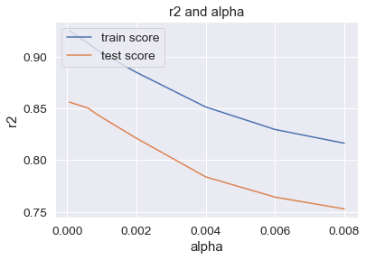

```python
# plotting mean test and train scoes with alpha
cv_results['param_alpha'] = cv_results['param_alpha'].astype('float32')

# plotting
plt.plot(cv_results['param_alpha'], cv_results['mean_train_score'])
plt.plot(cv_results['param_alpha'], cv_results['mean_test_score'])
plt.xlabel('alpha')
plt.ylabel('r2')

plt.title("r2 and alpha")
plt.legend(['train score', 'test score'], loc='upper left')
plt.show()
```

```python
#optimum alpha

alpha =0.001

lasso = Lasso(alpha=alpha)

lasso.fit(X_train, y_train)
```

```
Lasso(alpha=0.001)
```

```python
lasso.coef_
```

```
array([-4.09356126e-04,  1.41043514e-06,  1.80666838e-05,  4.75861642e-05,
        4.91108947e-05,  5.55828023e-05,  3.22848128e-05,  1.72776225e-04,
        1.95176491e-04, -2.93129965e-05,  2.33960625e-05,  4.05631982e-02,
        8.97338843e-04,  4.46795488e-02,  3.11477938e-02,  1.36517476e-03,
       -9.96565920e-02,  9.16320797e-03,  4.00955714e-02,  6.11563721e-02,
        3.68096081e-05,  1.11663349e-04, -4.88469932e-05,  1.16324360e-04,
        1.94148996e-04,  2.48687005e-04, -4.72011474e-04, -3.65282465e-06,
        4.33777426e-04, -2.04610388e-03,  0.00000000e+00, -1.01268932e-01,
        3.91866781e-02,  0.00000000e+00,  0.00000000e+00, -0.00000000e+00,
        0.00000000e+00,  0.00000000e+00, -0.00000000e+00, -4.15042585e-02,
        0.00000000e+00, -0.00000000e+00,  0.00000000e+00,  0.00000000e+00,
       -7.80791267e-02,  7.18055960e-03, -3.22277887e-02,  0.00000000e+00,
       -3.77577996e-03,  0.00000000e+00,  3.38538223e-02, -0.00000000e+00,
       -0.00000000e+00, -0.00000000e+00, -0.00000000e+00, -0.00000000e+00,
        0.00000000e+00,  1.71369941e-02,  0.00000000e+00,  9.80444492e-02,
       -8.59137343e-02, -0.00000000e+00, -8.30818267e-02, -5.23364891e-02,
       -0.00000000e+00, -0.00000000e+00, -0.00000000e+00, -0.00000000e+00,
        5.01165152e-02,  8.35409554e-02, -6.64082200e-02, -0.00000000e+00,
       -2.44227454e-02,  0.00000000e+00,  7.89978723e-02,  0.00000000e+00,
       -0.00000000e+00,  0.00000000e+00, -0.00000000e+00,  0.00000000e+00,
       -5.28335449e-02, -0.00000000e+00,  0.00000000e+00, -1.65696232e-02,
        0.00000000e+00,  0.00000000e+00, -2.16748081e-02, -5.48248917e-02,
        1.97772557e-01, -3.46471618e-02,  4.58670213e-02, -0.00000000e+00,
        0.00000000e+00,  1.19965493e-01, -0.00000000e+00, -3.67128819e-02,
       -5.74182905e-02,  0.00000000e+00, -2.10164729e-01,  1.81661568e-02,
       -0.00000000e+00,  0.00000000e+00, -0.00000000e+00,  4.52511947e-04,
        0.00000000e+00, -0.00000000e+00, -0.00000000e+00,  0.00000000e+00,
       -3.00864512e-02,  0.00000000e+00,  0.00000000e+00, -1.55475193e-02,
       -0.00000000e+00,  0.00000000e+00,  1.91566681e-03,  0.00000000e+00,
        0.00000000e+00,  1.48848904e-02, -0.00000000e+00, -0.00000000e+00,
        2.00200834e-03,  0.00000000e+00, -0.00000000e+00, -2.85976366e-02,
        1.39387050e-03, -1.77039340e-02,  0.00000000e+00, -0.00000000e+00,
        2.94541370e-02, -0.00000000e+00, -1.68470979e-02, -0.00000000e+00,
       -9.02099626e-03,  5.82368003e-02, -0.00000000e+00, -1.19803050e-02,
       -2.45862057e-02,  0.00000000e+00,  3.15878285e-02, -0.00000000e+00,
       -0.00000000e+00, -7.25667018e-05, -3.40816817e-02, -0.00000000e+00,
       -0.00000000e+00, -0.00000000e+00, -1.23665915e-02, -3.22899864e-02,
       -7.41505487e-03, -1.68877399e-02, -0.00000000e+00, -1.82728113e-02,
       -9.53528110e-03, -3.85783311e-02, -3.24128882e-04, -0.00000000e+00,
       -1.72777053e-02,  2.96218009e-02,  0.00000000e+00,  4.22153542e-02])
```

```python
lasso.score(X_train,y_train)
```

```
0.898288939025357
```

```python
lasso.score(X_test,y_test)
```

```
0.8646575331441891
```

```python
# lasso model parameters
model_parameters = list(sorted(lasso.coef_))
model_parameters.insert(0, lasso.intercept_)
model_parameters = [round(x, 3) for x in model_parameters]
cols = X.columns
cols = cols.insert(0, "constant")
list((zip(cols, model_parameters)))
```

```
[('constant', 11.482),
 ('LotFrontage', -0.21),
 ('LotArea', -0.101),
 ('MasVnrArea', -0.1),
 ('BsmtFinSF1', -0.086),
 ('BsmtFinSF2', -0.083),
 ('BsmtUnfSF', -0.078),
 ('TotalBsmtSF', -0.066),
 ('1stFlrSF', -0.057),
 ('2ndFlrSF', -0.055),
 ('LowQualFinSF', -0.053),
 ('GrLivArea', -0.052),
 ('BsmtFullBath', -0.042),
 ('BsmtHalfBath', -0.039),
 ('FullBath', -0.037),
 ('HalfBath', -0.035),
 ('BedroomAbvGr', -0.034),
 ('KitchenAbvGr', -0.032),
 ('TotRmsAbvGrd', -0.032),
 ('Fireplaces', -0.03),
 ('GarageCars', -0.029),
 ('GarageArea', -0.025),
 ('WoodDeckSF', -0.024),
 ('OpenPorchSF', -0.022),
 ('EnclosedPorch', -0.018),
 ('3SsnPorch', -0.018),
 ('ScreenPorch', -0.017),
 ('PoolArea', -0.017),
 ('MiscVal', -0.017),
 ('MoSold', -0.017),
 ('YearSinceRemodel', -0.016),
 ('MSSubClass_1-1/2 STORY FINISHED ALL AGES', -0.012),
 ('MSSubClass_1-STORY 1945 & OLDER', -0.012),
 ('MSSubClass_1-STORY 1946 & NEWER ALL STYLES', -0.01),
 ('MSSubClass_1-STORY PUD (Planned Unit Development) - 1946 & NEWER', -0.009),
 ('MSSubClass_1-STORY W/FINISHED ATTIC ALL AGES', -0.007),
 ('MSSubClass_2 FAMILY CONVERSION - ALL STYLES AND AGES', -0.004),
 ('MSSubClass_2-1/2 STORY ALL AGES', -0.002),
 ('MSSubClass_2-STORY 1945 & OLDER', -0.0),
 ('MSSubClass_2-STORY 1946 & NEWER', -0.0),
```

[output cut: 106 more lines]

```
 ('HeatingQC_Po', 0.034),
 ('HeatingQC_TA', 0.039),
 ('KitchenQual_Fa', 0.04),
 ('KitchenQual_Gd', 0.041),
 ('KitchenQual_TA', 0.042),
 ('GarageType_BuiltIn', 0.045),
 ('GarageType_Detchd', 0.046),
 ('GarageType_No Garage', 0.05),
 ('GarageType_Others', 0.058),
 ('GarageFinish_No Garage', 0.061),
 ('GarageFinish_RFn', 0.079),
 ('GarageFinish_Unf', 0.084),
 ('SaleCondition_Normal', 0.098),
 ('SaleCondition_Others', 0.12),
 ('SaleCondition_Partial', 0.198)]
```

## Conclusion :

-we got a decent score for both Ridge and Lasso regression.

-Ridge : Train :90.9 Test :87.4

-Lasso : Train :89.8 Test :86.4

## These Varaiables are directly proportional to each other.

### Because of Feature selection as well we can choose Lasso regression in this case.